# Problem Statement:

# What are the correlations between numerical variables like year, KM Driven, and price?

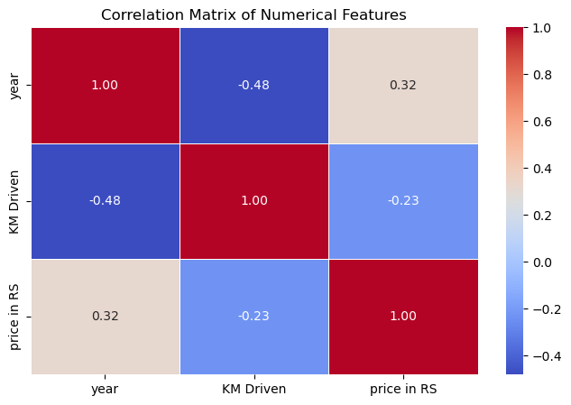

```python
# Selecting numerical columns
numeric_cols = ['year', 'KM Driven', 'price in RS']

# Compute correlation matrix
correlation_matrix = df[numeric_cols].corr()

# Plot heatmap
plt.figure(figsize=(8,5))
sns.heatmap(correlation_matrix, annot=True, cmap='coolwarm', fmt=".2f", linewidths=0.5)
plt.title("Correlation Matrix of Numerical Features")
plt.show()
```

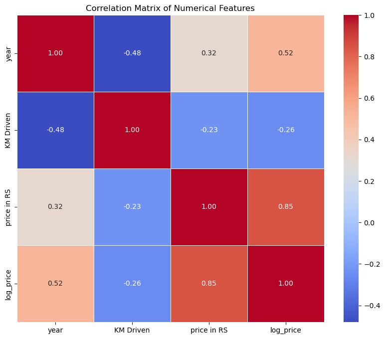

```python
# Selecting numerical columns
numeric_cols = ['year', 'KM Driven', 'price in RS', 'log_price']

# Compute correlation matrix
correlation_matrix = df[numeric_cols].corr()

# Plot heatmap
plt.figure(figsize=(10,8))
sns.heatmap(correlation_matrix, annot=True, cmap='coolwarm', fmt=".2f", linewidths=0.5, square=True)
plt.title("Correlation Matrix of Numerical Features")
plt.show()
```

# The heatmap represents the **correlation** between numerical variables in the dataset. The values range from **-1 to 1**, where:

- **1.00** → Perfect positive correlation (as one variable increases, the other also increases).
- **-1.00** → Perfect negative correlation (as one variable increases, the other decreases).
- **0.00** → No correlation.

### **Conclusion:**

- **Newer cars are generally more expensive.**
- **Higher mileage cars tend to have lower prices.**
- **Older cars typically have more kilometers driven.**

Would you like insights on how this can be used for car recommendations? 🚗📊

```python
df.columns
```

```
Index(['model', 'brand', 'year', 'location', 'fuel', 'KM Driven',
       'price in RS', 'log_price'],
      dtype='object')
```

```python
df.head()
```

|  | model | brand | year | location | fuel | KM Driven | price in RS | log_price |
| --- | --- | --- | --- | --- | --- | --- | --- | --- |
| 0 | 2022 Mercedes-Benz GLS 400d 4MATIC [2020-2023] | Mercedes | 2022 | Banjara Hills | Diesel | 42340 | 12000000 | 16.300417 |
| 1 | 2022 BMW X1 sDrive20d xLine | BMW | 2022 | Jubilee Hills | Diesel | 49500 | 3450000 | 15.053885 |
| 2 | 2022 Nissan Magnite XL Turbo CVT | Nissan | 2022 | Madhapur | Petrol | 18072 | 825000 | 13.623140 |
| 3 | 2017 Hyundai Creta 1.6 S Plus AT | Hyundai | 2017 | Attapur | Diesel | 87900 | 1100000 | 13.910822 |
| 4 | 2016 Land Rover Range Rover Evoque HSE | Land | 2016 | Begumpet | Diesel | 133457 | 2500000 | 14.731802 |

# insights

# Here are the insights from your analysis:

Univariate Analysis

[output not shown]

Bivariate Analysis

```
Price vs. Fuel Type: Petrol cars are generally priced lower than Diesel and Electric cars.
Price vs. Brand: Luxury brands like Bentley, Porsche, and Mercedes tend to have higher prices, while affordable brands like Maruti, Hyundai, and Tata have lower prices.
Age vs. Price: Newer cars tend to be more expensive, while older cars generally have lower prices.
```

Multivariate Analysis

```
KM Driven, Fuel Type, and Price: Cars with higher KM Driven tend to have lower prices, regardless of fuel type. Electric and Hybrid cars maintain their value better, even with higher mileage.
Brand, KM Driven, and Price: Luxury brands tend to retain their value better, even with higher KM Driven, while affordable brands depreciate faster.
```

Key Takeaways

```
Newer cars are more expensive: A positive correlation between year and price.
Higher mileage cars are cheaper: A negative correlation between KM Driven and price.
Luxury brands retain value better: Luxury brands like Bentley, Porsche, and Mercedes tend to have higher prices, regardless of KM Driven.
Electric and Hybrid cars maintain value: Electric and Hybrid cars tend to retain their value better, even with higher mileage.
```

These insights provide a comprehensive understanding of the used car market, highlighting trends, correlations, and patterns in car prices, brands, fuel types, and mileage.

# Here's a suggested outline to present your project in an interview:

Introduction (1-2 minutes)

```
Start with a brief introduction to the project:
    "For my project, I worked on web scraping and data analysis of the used car market using data from CarWale."
    "The goal was to extract insights and trends from the data to better understand the market."
```

Problem Statement and Data Collection (1-2 minutes)

```
Explain the problem statement:
    "The used car market is vast and complex, with numerous factors influencing car prices."
    "I aimed to collect and analyze data to identify patterns and trends in car prices, brands, fuel types, and mileage."
Describe the data collection process:
    "I used Beautiful Soup and Requests libraries to web scrape data from CarWale."
    "I collected data on over 5700 cars, including title, km driven, price, fuel type, location, and more."
```

Data Preprocessing and Analysis (2-3 minutes)

[output not shown]

Key Insights and Findings (3-4 minutes)

```
Present the key insights and findings from your analysis:
    "Newer cars tend to be more expensive, while older cars generally have lower prices."
    "Higher mileage cars tend to be cheaper, regardless of fuel type."
    "Luxury brands like Bentley, Porsche, and Mercedes tend to retain their value better, even with higher mileage."
    "Electric and Hybrid cars maintain their value better, even with higher mileage."
```

Conclusion and Future Work (1-2 minutes)

```
Summarize the key takeaways from your project:
    "This project provided valuable insights into the used car market, highlighting trends and patterns in car prices, brands, fuel types, and mileage."
Discuss potential future work or extensions to the project:
    "Future work could involve incorporating additional data sources, such as car reviews or ratings, to further enhance the analysis."
    "Another potential extension could be to develop a predictive model to forecast car prices based on various factors."
```

Be Prepared to Answer Questions

```
Be ready to answer questions from the interviewer, such as:
    How did you handle missing values or outliers in the data?
    Can you explain the correlation analysis you performed?
    How do you think this project could be applied in a real-world setting?
```